# Introduction to statistics

author: Alejandro Cáceres date:  
autosize: true

Barcelona East School of Engineering  
Universitat Politècnica de Catalunya (UPC)

Lecture 5

# Objective

Continuous probability models

- Exponential probability density function
- Uniform probability density function
- Normal probability density function

# Continuous probability models

Continuous probability models follow from considering probability density functions $f(x)$ of a continuous random variable $X$ that we **believe** describe processes like real random experiments.

Definition:

- $f(x) \geq 0$
- $\int_{-\infty}^{\infty} f(x) dx = 1$
- $P(a\leq X \leq b)=\int_{a}^{b} f(x) dx$

# Continuous probability models

- remember that these are abstract objects and may or may not represent any natural/engineered process.
- as in the discrete case we will build up the models from the basic requirements of what we believe natural natural processes could satisfy.

# Exponential density

Let’s go back to the Poisson probability for the number of events ($k$) in an interval

$f(k)=\frac{e^{-\lambda}\lambda^k}{k!}, \lambda>0$

Remember that we introduced additional randomness at which the Bernoulli trials happen, but still expected that within an interval we know the average number of events $\lambda$.

# Exponential density

- Let’s now consider only two consecutive (length/time) events
- the distance between them is a **continuous** random variable.

We can ask for the probability that two events are distanced $X$.

# Exponential density

When we asked for the probability across different intervals lengths we had to re-escale $\lambda$ in some units by the interval of interest

$E_x(K)=x \lambda$

$K$ the number of events in the interval $x$, in units of $\lambda$

$f(k)=\frac{e^{-x\lambda}{(x\lambda)}^k}{k!}, x\lambda>0$

Let us consider an interval of size $x$ that measures the length between any two events (say until the fist event).

What is the probability ob observing $0$ events in an interval of length of $x$?

# Exponential density

The density is of the form

$f(k=0|x)= \frac{e^{-x\lambda}{(x\lambda)}^0}{0!}=e^{-\lambda x}$

Let’s think of $x$ as the result of measuring the interval we need to wait between two events. The interval $X$ is a random variable and $x$ is one value of an experiment.

# Exponential density

What is the probability of observing $x$ as the interval with no events?

We want the probability of $x$ when $k=0$: $f(x|k=0)$

The density is of the form

$P(X=x) = f(x| k=0) dx = \frac{f(k=0|x)f(x)}{f(k=0)}dx$

We can consider that the marginal probability of observing $f(x)$ is a constant: it is the probability of selecting an interval of size $x$ randomly, not conditioned to the Poisson process. $f(k=0)$ is also a constant. Therefore,

$P(X=x) = f(x; k=0) dx = C e^{-\lambda x}$

$C$ is a constant that ensures: $\int f(x; k=0) dx =1$, then by integration $C=\lambda$

$$P(X=x) = \lambda e^{-\lambda x}$$

We have seen this density before!

# Exponential density

A line production process requires to drill a hole of $12.5mm$ in a metallic disc. Sometimes the drill moves and opens slightly larger holes

- We **believed** that
  $$f(x)=20 e^{-20(x-12.5)}$$
  for $12.5 \leq x$ and $f(x)=0$ for $x\leq 12.5$

we changed the variable: $z=x-12.5$ and $\lambda=20$

$f(z)=\lambda e^{-\lambda z}, z\geq 0$

# Exponential density

For the exponential density $f(z)=\lambda e^{-\lambda z}, z\geq 0$

we showed

- Mean: $\mu_z=E(Z)=\frac{1}{\lambda}$
- Variance: $V(Z)=\frac{1}{\lambda^2}$

# Exponential density

¿What is the probability of observing an interval less than $x$ until the first event?

Remember that this probability $P(X \leq x)=F(x)$ is the probability density

$P(X\leq x)=\lambda \int_\infty^b e^{-x\lambda}dx=e^{-x\lambda} - 1$

¿What is the probability of observing an interval more than $x$ until the first event?

$P(X \geq x)=1- P(X \leq x)= 1- F(x)$

# Exponential density

Note: the exponential density can describe the drilling of a whole or the times (distances) between Poisson counts.

- Probability models can be used to describe very different natural/engineered processes.
- The main challenge in real-world statistics:

Which model to chose in a particular experiment?

# Uniform density

A probability density function can also be obtained from the discrete uniform probability function

- $n$ outcomes have each $P(X=x)=1/n$
- when $n \rightarrow \infty$

If $X$ takes values in $(a,b)$, the probability density will be constant on the interval

$$f(x)=
\begin{cases}
\frac{1}{b-a},& \text{if } x\in (a,b)\\
0,& otherwise
\end{cases}$$

# Uniform density

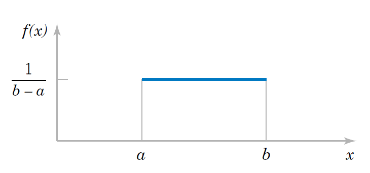

# Uniform density

What are the mean and variance of the uniform density?

- For the mean we have

$E(X)=\int_{a}^{b} \frac{1}{b-a} x dx=\frac{1}{2}\frac{x^2}{b-a}\big|_a^b=\frac{a+b}{2}$

- For the variance we have

$V(X)=\int_{a}^{b} \frac{1}{b-a} (x-\mu)^2 dx=\frac{1}{3}\frac{\big(x -\frac{a+b}{2}\big)^3}{b-a}\big|_a^b=\frac{(b-a)^2}{12}$

the same as the discrete case! because $E(X)$ and $V(X)$ do not depend on $n$.

The probability density is

$F(x)=\frac{x}{b-a}$ if $x\in (a,b)$ ($0$ if $x<a$ and $1$ if $x>b$)

# Normal density

- The normal density probability function is the queen of the probability densities
- Discovered by the prince of mathematics Carl Friedrich Gauss
- It also called the Gaussian probability density

# Normal density

In 1801 Gauss analyzed the orbit of Ceres (large asteroid between Mars and Jupiter).

- People suspected it was a new planet.
- The measurements had errors.
- He was interested in finding how the observations were distributed so he could find the most probable orbit.
- He wanted to predict where astronomers could point their telescopes to find it after it cross in front of the Sun.

# Normal density

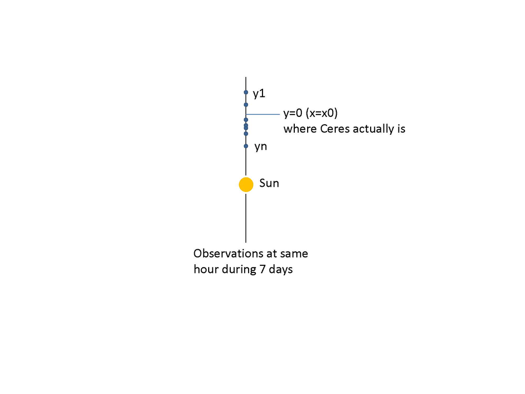

# Normal density

He assumed that

- small errors were more likely than large errors
- error at a distance $-\epsilon$ or $\epsilon$ from the most likely measurement were equally likely
- the most **likely** altitude of Ceres at a given time in the sky was the **average** of multiple altitude measurements at that latitude.

# Normal density

That was enough to show that the random deviations $y$ **from the orbit** distributed like

$f(y)=\frac{h}{\sqrt{\pi}}e^{-h^2y^2}$

*The evolution of the Normal distribution, Saul Stahl, Mathematics Magazine, 2006.

# Normal density

$f(y)=\frac{h}{\sqrt{\pi}}e^{-h^2y^2}$

Let’s write it in a more general form:

Imagine measurements $X$ for the altitude of Ceres from an origin (horizon) that concentrate around a value $x_0$, then $y=x-x_0$. If $x$ is one measurement of altitude from the horizon then its probability density function is

$f(x)=\frac{h}{\sqrt{\pi}}e^{-h^2(x-x_0)^2}$

and its mean is:  
$E(X)=\int_{-\infty}^{\infty} x \frac{h}{\sqrt{\pi}}e^{-h^2(x-x_0)^2}dx =x_0$

Wich can be proven by its moment generating function:

$M_X(t)= E(e^{tx})=e^{x_0 t+\frac{t^2}{2h^2}}$; $M'_X(t)=E(X)=\mu=M_X(t)(x_0+\frac{t}{2h^2})\Big|_{t=0}=x_0$

# Normal density

And, for the variance, we find:

$E(X^2)=M''_X(t)(\mu^2+\frac{1}{2h^2})\Big|_{t=0}=\mu^2+\frac{1}{2h^2}$

and since $E(X^2)=V(X)+\mu^2=\sigma^2+\mu^2$ then $\sigma^2=\frac{1}{2h^2}$

Replacing the values of $\mu=x_0$ and $h^2=\frac{1}{2\sigma^2}$ in $f(x)$ we can write the normal density function of **parameters** $\mu$ and $\sigma$

$f(x; \mu, \sigma^2)=\frac{1}{\sqrt{2\pi}\sigma}e^{-\frac{(x-\mu)^2}{2\sigma^2}}, x \in {\Bbb R}$

with mean $E(X)=\mu$ and variance $V(X)=\sigma^2$.

# Normal density

**Definition**

A random variable $X $defined in the real numbers has a **Normal** density if it takes the form

$f(x; \mu, \sigma^2)=\frac{1}{\sqrt{2\pi}\sigma}e^{-\frac{(x-\mu)^2}{2\sigma^2}}, x \in {\Bbb R}$

con mean

$E (X) = \mu$

and variance

$V (X) = \sigma^2$.

When $X$ follows a Normal density we write

$$X\hookrightarrow N(\mu,\sigma^2)$$

# Normal density

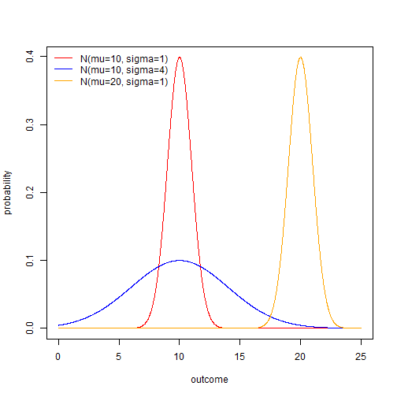

# Normal density

Let’s change variables to a **standardized variable**

$Z=\frac{X-\mu}{\sigma}$

in the density

$f(x; \mu, \sigma^2)=\frac{1}{\sqrt{2\pi}\sigma}e^{-\frac{(x-\mu)^2}{2\sigma^2}}, x \in {\Bbb R}$

replacing $x=\sigma z+\mu$ and $dx=\sigma dz$ in the probability expression we have

$P(x\leq X \leq x +dx)=P(z\leq Z \leq z +dz)$  
$=\frac{1}{\sqrt{2\pi}\sigma}e^{-\frac{(x-\mu)^2}{2\sigma^2}}dx=\frac{1}{ \sqrt{2\pi}}e^{-\frac{z^2}{2}} dz$

we obtain the **standardized** form of the normal density.

# Normal density

**Definition**

A random variable $Z$ defined in the real numbers has a **standard** density if it takes the form

$f(z)=\frac{1}{\sqrt{2\pi}}e^{-\frac{z^2}{2}} dz,z \in {\Bbb R}$

with mean

$E (X) = 0$

and variance

$V (X) =1$.

# Normal density

$f(z)=\frac{1}{\sqrt{2\pi}}e^{-\frac{z^2}{2}} dz,z \in {\Bbb R}$

- the standard density is the normal density $N(\mu=0,\sigma^2=1)$
- any normally distributed variable $X$ can be transformed to a variable $Z$ that distributes normally by standardization $Z=(x-\mu)/\sigma$

# Normal density

The probability distribution of the standard density is the **error** function defined by

$\Phi (z)=P(Z\leq z)=\int_{-\infty}^{z} \frac{1}{\sqrt{2\pi}}e^{-\frac{z^2}{2}} dz$

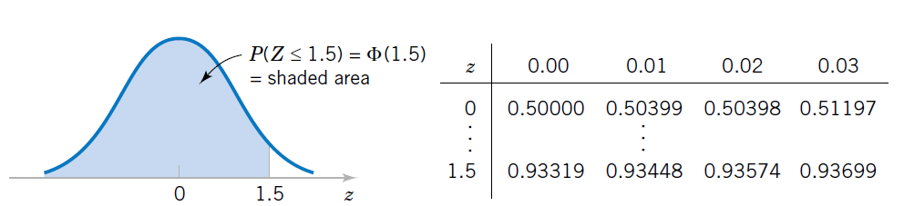

You can find it tabulated or in computer programs

# Normal density

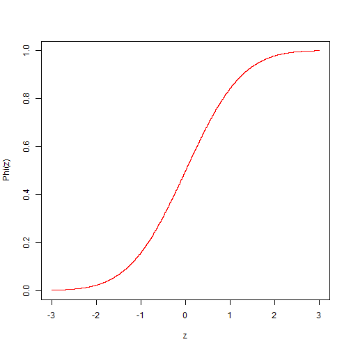

# Normal density

For any normally distributed variable $X$, such that

$X\hookrightarrow N(\mu, \sigma^2)$

its distribution can be computed from

$F(x)= \Phi \big(\frac{x-\mu}{\sigma}\big)$

# Standard density

For computing $P(a\leq X \leq b)$, we use the property of the probability distributions

$P(a\leq X \leq b) = F(b)-F(a)=P(X\leq b)-P(X\leq a)$

Let’s standardize

$=P(Z \leq \frac{b-\mu}{\sigma})-P(Z \leq \frac{a-\mu}{\sigma}\big)$

$=\Phi \big(\frac{b-\mu}{\sigma}\big)-\Phi \big(\frac{a-\mu}{\sigma}\big)$

# Standard density

All normal densities can be obtained from the standard density with the values of $\mu$ and $\sigma$

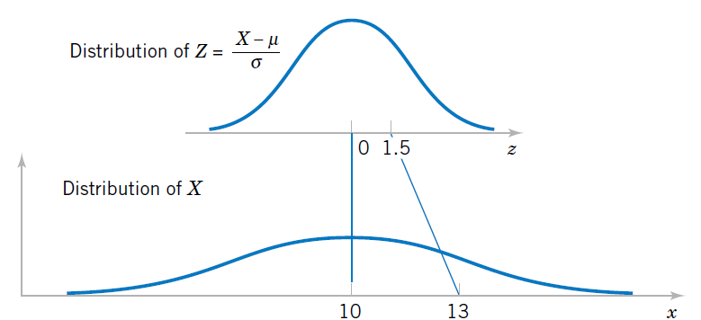

# Normal density

Remember our motivations for Chebyshev’s theorem.

We wanted to know if

- the outcomes should concentrate on probability around the mean
- the outcomes should decrease in probability far from the mean.

Theorem: $P(|X -\mu| \geq a\sigma) \leq \frac{1}{a^2}$

# Normal density

[output not shown]

# Normal density

# Normal density

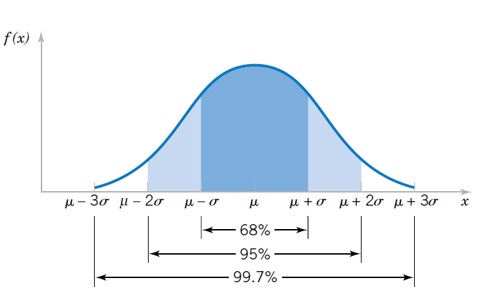

# Normal density

Why is the normal density so important?

- The average of the measurements of many random variables can be approximated by a normal density (it doesn’t matter how the measurements distribute themselves)
- Binomial and Poisson processes with many trials ($n \rightarrow \infty$) tend to the normal density

# Summary of probability models

| Model | X | range of x | f(x) | E(X) | V(X) | R |
| --- | --- | --- | --- | --- | --- | --- |
| Uniform | integer or real number | $[a, b]$ | $\frac{1}{n}$ | $\frac{b+a}{2}$ | $\frac{(b-a+1)^2-1}{12}$ | `rep(1/n, n)`, `dunif(x, a, b)` |
| Bernoulli | event A | 0,1 | $(1-p)^{1-x}p^x$ | $p$ | $p(1-p)$ | `c(1-p,p)` |
| Binomial | # of A events in $n$ repetitions of Bernoulli trials | 0,1,… | $\binom n x (1-p)^{n-x}p^x$ | $np$ | $np(1-p)$ | `dbimon(x,n,p)` |
| Geometric for events | # of B events in Bernoulli repetitions before A is observed | 0,1,… | $(1-p)^{x}p$ | $\frac{1-p}{p}$ | $\frac{1-p}{p^2}$ | `dgeom(x,p)` |
| Geometric for trials | # Bernoulli trials before A is observed | 1,… | $(1-p)^{x-1}p$ | $\frac{1}{p}$ | $\frac{1}{p^2}$ | `dgeom(x-1,p)` |
| Negative Binomial for events | # of B events in Bernoulli repetitions before $r$ As are observed | 0,1,.. | $\binom {x+r-1} x (1-p)^xp^r$ | $\frac{r(1-p)}{p}$ | $\frac{r(1-p)}{p^2}$ | `dnbinom(x,r,p)` |
| Negative Binomial for trials | # of Bernoulli repetitions before $r$ As are observed | r,r+1,.. | $\binom {x-1} {r-1} (1-p)^{x-r} p^r$ | $\frac{r}{p}$ | $\frac{r(1-p)}{p^2}$ | `dnbinom(x-r,r,p)` |
| Hypergeometrico | # A events in a sample $n$ from population $N$ with $K$ As | $\max(0, n+K-N)$, … $\min(K, n)$ | $\frac{1}{\binom N n}\binom K x \binom {N-K} {n-x}$ | $n*\frac{N}{K}$ | $n \frac{N}{K} (1-\frac{N}{K})\frac{N-n}{N-1}$ | `dhyper(x, K, N-K, n)` |
| Poisson | # of events A in an interval | 0,1, .. | $\frac{e^{-\lambda}\lambda^x}{x!}$ | $\lambda$ | $\lambda$ | `dpoiss(x, lambda)` |
| Exponential | Interval between two events A | $[0,\infty)$ | $\lambda e^{-\lambda x}$ | $\frac{1}{\lambda}$ | $\frac{1}{\lambda^2}$ | `dexp(x, lambda)` |
| Normal | measurement with symmetric errors whose most likely value is the average | $(-\infty, \infty)$ | $\frac{1}{\sqrt{2\pi}\sigma}e^{-\frac{(x-\mu)^2}{2\sigma^2}}$ | $\mu$ | $\sigma^2$ | `dnomr(x, mu, sigma)` |

# Exercise

Estamos interesados en estudiar el tiempo de espera en una determinada parada de una linea de autobuses urbanos. En condiciones de tráﬁco normal, el número de autobuses que pasan cada hora por la parada es una variable aleatoria que tiene distribución de Poisson con parámetro λ = 6 autobuses/hora.

1. Un viajero llega a la parada en el momento justo que acaba de salir el autobús. Calcula la probabilidad de que tenga de esperar más de 20 minutos hasta la llegada del próximo autobús.
2. Un viajero ha llegado a la parada en el momento justo que acababa de salir el autobús, y lleva 10 minutos esperando. Calcula la probabilidad de que, a partir de ese momento, tenga de esperar menos de 10 minutos adicionales hasta la llegada del próximo autobús.